# Machine Learning Practice

## IBM Employee Attrition Prediction Phase I

## IBM员工流失预测 I

保持员工满意的问题是一个长期存在且历史悠久的挑战。如果企业投入了大量时间和金钱的员工离开，那么这意味着企业将不得不花费更多的时间和金钱来雇佣其他人。这个项目使用了IBM的员工流失数据作为处理目标，看看是否可以构建一些模型，来对员工的流失进行预测。

## 该练习的结构如下：

1. 探索性数据分析：通过查看特征分布，一个特征与另一个特征的相关性以及创建一些可视化图表来探索数据集。
2. 特征工程：执行一些简单的特征处理工作。
3. 实现机器学习模型：尝试多种机器学习模型，从这些模型中查看参数对结果的影响。

## 探索数据

```python
import numpy as np
import pandas as pd
import matplotlib.pyplot as plt
from sklearn.ensemble import RandomForestClassifier, GradientBoostingClassifier
from sklearn.linear_model import LogisticRegression
from sklearn.metrics import accuracy_score, log_loss
from sklearn.preprocessing import OneHotEncoder, MinMaxScaler ,LabelEncoder
import warnings
warnings.filterwarnings('ignore')
```

```python
# Load data file
attrition = pd.read_csv('../data/IBM_Employee_Attrition.csv')
attrition.head()
```

|  | Age | Attrition | BusinessTravel | DailyRate | Department | DistanceFromHome | Education | EducationField | EmployeeCount | EmployeeNumber | ... | RelationshipSatisfaction | StandardHours | StockOptionLevel | TotalWorkingYears | TrainingTimesLastYear | WorkLifeBalance | YearsAtCompany | YearsInCurrentRole | YearsSinceLastPromotion | YearsWithCurrManager |
| --- | --- | --- | --- | --- | --- | --- | --- | --- | --- | --- | --- | --- | --- | --- | --- | --- | --- | --- | --- | --- | --- |
| 0 | 41 | Yes | Travel_Rarely | 1102 | Sales | 1 | 2 | Life Sciences | 1 | 1 | ... | 1 | 80 | 0 | 8 | 0 | 1 | 6 | 4 | 0 | 5 |
| 1 | 49 | No | Travel_Frequently | 279 | Research & Development | 8 | 1 | Life Sciences | 1 | 2 | ... | 4 | 80 | 1 | 10 | 3 | 3 | 10 | 7 | 1 | 7 |
| 2 | 37 | Yes | Travel_Rarely | 1373 | Research & Development | 2 | 2 | Other | 1 | 4 | ... | 2 | 80 | 0 | 7 | 3 | 3 | 0 | 0 | 0 | 0 |
| 3 | 33 | No | Travel_Frequently | 1392 | Research & Development | 3 | 4 | Life Sciences | 1 | 5 | ... | 3 | 80 | 0 | 8 | 3 | 3 | 8 | 7 | 3 | 0 |
| 4 | 27 | No | Travel_Rarely | 591 | Research & Development | 2 | 1 | Medical | 1 | 7 | ... | 4 | 80 | 1 | 6 | 3 | 3 | 2 | 2 | 2 | 2 |

5 rows × 35 columns

## 观察

从员工流失数据样本中，我们可以看到数据的一些特征：

在即将构建的机器学习模型当中，'Attrition'将是模型训练的目标列。

此外，可以看到混合了数字和分类数据类型。本次将专注于数字类型的相关属性探索。

作为第一步，快速进行一些简单的数据完整性检查，以查看数据中是否存在空值或无效值。

```python
# Check the null value
attrition.isnull().sum()
```

```
Age                         0
Attrition                   0
BusinessTravel              0
DailyRate                   0
Department                  0
DistanceFromHome            0
Education                   0
EducationField              0
EmployeeCount               0
EmployeeNumber              0
EnvironmentSatisfaction     0
Gender                      0
HourlyRate                  0
JobInvolvement              0
JobLevel                    0
JobRole                     0
JobSatisfaction             0
MaritalStatus               0
MonthlyIncome               0
MonthlyRate                 0
NumCompaniesWorked          0
Over18                      0
OverTime                    0
PercentSalaryHike           0
PerformanceRating           0
RelationshipSatisfaction    0
StandardHours               0
StockOptionLevel            0
TotalWorkingYears           0
TrainingTimesLastYear       0
WorkLifeBalance             0
YearsAtCompany              0
YearsInCurrentRole          0
YearsSinceLastPromotion     0
YearsWithCurrManager        0
dtype: int64
```

- **观察发现，数据集中没有缺失值。**
- **如果存在缺失值，处理的办法包括删除缺失值，人工填写，用特殊值填写等，需要根据缺失值所占比例或者特征的重要性等情况来具体分析处理。**

## 数据集的分布

通常，探索数据的前几个步骤之一就是大致了解这些特征如何分布。

直觉的判断，年龄(Age)、日工作效率（DailyRate）、员工满意度（JobSatisfaction）、月收入（MonthlyIncome）、工作表现（PerformanceRating）、工作生活平衡性（WorkLifeBalance）、进入公司年限（YearsAtCompany）这些属性与所关注的员工是否离职应有莫大的关系。

为此，将从Seaborn绘图库调用 pairplot 函数，将这些属性之间的关系用可视化的方式表示出来。

```python
import seaborn as sns
# 将dataframe类型变量attrition中的Attrition列转化为Int类型，并放入一个新建的属性Attrition_numerical中。
# Attrition列中的元素与Attrition_numerical元素的值对应关系是：'Yes'=>1，'No'=>0
attrition['Attrition_numerical'] = attrition['Attrition'].apply(lambda x: 1 if x == 'Yes' else 0)

# 定义要绘制两两关系的属性列
numerical = [u'Age', u'DailyRate',  u'JobSatisfaction',
       u'MonthlyIncome', u'PerformanceRating',
        u'WorkLifeBalance', u'YearsAtCompany', u'Attrition_numerical']
```

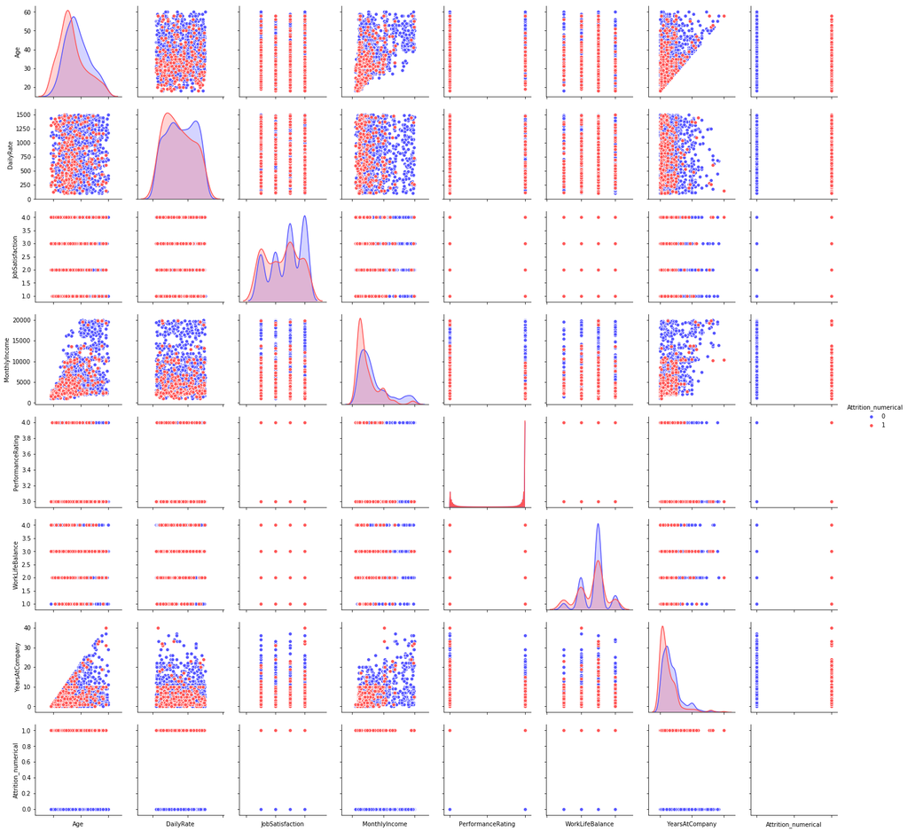

```python
# 绘制关系图
g = sns.pairplot(attrition[numerical], hue='Attrition_numerical', palette='seismic',
                diag_kind='kde', diag_kws=dict(shade=True))
g.set(xticklabels=[])
plt.show()
```

## 观察

在上图中，红色的点代表离职，蓝色代表未离职。

可以看到一些有意思的结果，比如在MonthlyIncome与YearsAtCompany交汇的这张图中，红色点更趋向集中于左下角，这很明显地说明了MonthlyIncome与YearsAtCompany都相对较低时，员工容易出现离职的情况。

再比如在YearsAtCompany这行对应的DailyRate这张图中，DailyRate的变化似乎对员工是否离职没有太多的影响。红色点集中于图像下部，YearsAtCompany小的员工相对更容易出现离职情况而与DailyRate没什么关系。

## 探索

- 首先将员工的流失情况记录下来，并将其从原表中删除

```python
# 使用变量y记录attrition中'Attrition_numerical'这一列的值
y = attrition['Attrition_numerical']

# 将attrition中的'Attrition'以及'Attrition_numerical'列删除
attrition = attrition.drop(['Attrition', 'Attrition_numerical'], axis=1)

attrition.head()
```

|  | Age | BusinessTravel | DailyRate | Department | DistanceFromHome | Education | EducationField | EmployeeCount | EmployeeNumber | EnvironmentSatisfaction | ... | RelationshipSatisfaction | StandardHours | StockOptionLevel | TotalWorkingYears | TrainingTimesLastYear | WorkLifeBalance | YearsAtCompany | YearsInCurrentRole | YearsSinceLastPromotion | YearsWithCurrManager |
| --- | --- | --- | --- | --- | --- | --- | --- | --- | --- | --- | --- | --- | --- | --- | --- | --- | --- | --- | --- | --- | --- |
| 0 | 41 | Travel_Rarely | 1102 | Sales | 1 | 2 | Life Sciences | 1 | 1 | 2 | ... | 1 | 80 | 0 | 8 | 0 | 1 | 6 | 4 | 0 | 5 |
| 1 | 49 | Travel_Frequently | 279 | Research & Development | 8 | 1 | Life Sciences | 1 | 2 | 3 | ... | 4 | 80 | 1 | 10 | 3 | 3 | 10 | 7 | 1 | 7 |
| 2 | 37 | Travel_Rarely | 1373 | Research & Development | 2 | 2 | Other | 1 | 4 | 4 | ... | 2 | 80 | 0 | 7 | 3 | 3 | 0 | 0 | 0 | 0 |
| 3 | 33 | Travel_Frequently | 1392 | Research & Development | 3 | 4 | Life Sciences | 1 | 5 | 4 | ... | 3 | 80 | 0 | 8 | 3 | 3 | 8 | 7 | 3 | 0 |
| 4 | 27 | Travel_Rarely | 591 | Research & Development | 2 | 1 | Medical | 1 | 7 | 1 | ... | 4 | 80 | 1 | 6 | 3 | 3 | 2 | 2 | 2 | 2 |

5 rows × 34 columns

## 属性类型判别

在数据当中有很多列的都是由字符串组成的，在对数据集进行了简要的探索之后，继续进行特征工程的任务，并对数据集中的某些非数值属性进行数字编码。

首先，使用dtype方法将数值列与非数值列分开。

```python
# Check the data type of ecah volumn
attrition.dtypes
```

```
Age                          int64
BusinessTravel              object
DailyRate                    int64
Department                  object
DistanceFromHome             int64
Education                    int64
EducationField              object
EmployeeCount                int64
EmployeeNumber               int64
EnvironmentSatisfaction      int64
Gender                      object
HourlyRate                   int64
JobInvolvement               int64
JobLevel                     int64
JobRole                     object
JobSatisfaction              int64
MaritalStatus               object
MonthlyIncome                int64
MonthlyRate                  int64
NumCompaniesWorked           int64
Over18                      object
OverTime                    object
PercentSalaryHike            int64
PerformanceRating            int64
RelationshipSatisfaction     int64
StandardHours                int64
StockOptionLevel             int64
TotalWorkingYears            int64
TrainingTimesLastYear        int64
WorkLifeBalance              int64
YearsAtCompany               int64
YearsInCurrentRole           int64
YearsSinceLastPromotion      int64
YearsWithCurrManager         int64
dtype: object
```

```python
# 用categoricals列表于记录所有的非数值属性名
categoricals = []

# 将非数值列的列名添加到列表categoricals中
for column in attrition.columns:
    if attrition[column].dtype == object:
        categoricals.append(column)

print(categoricals)
```

```
['BusinessTravel', 'Department', 'EducationField', 'Gender', 'JobRole', 'MaritalStatus', 'Over18', 'OverTime']
```

## 特征处理

采用get_dummies方法对非数值属性进行处理，将他们转化为数值的形式。 将非数值属性进行数字编码的原因是非数值型特征是不可以直接用于训练模型的，因为我们的模型大多都是数学模型，接触的特征是数值型数据。

```python
# 使用pandas中的get_dummies方法将非数值列转为数字，并用转化好的列替换掉原本的列

# 提取非数值类型并放到DataFrame类型的变量attrition_cat中
attrition_cat = attrition[categoricals]

# 使用pd.get_dummies将attrition_cat转换成数值形式并将结果覆盖赋值到原有变量attrition_cat之上
attrition_cat = pd.get_dummies(attrition_cat)

# 提取数值类型
# 获取attrition的数值类型属性列的所有数据，赋值到DataFrame类型的变量attrition_num上
attrition_num = attrition.drop(categoricals, axis=1)

# 将attrition_num与attrition_cat进行纵向拼接，生成新的DataFrame并赋值到变量attrition_final上
attrition_final = pd.concat([attrition_num, attrition_cat], axis=1)

attrition_final.head()
```

|  | Age | DailyRate | DistanceFromHome | Education | EmployeeCount | EmployeeNumber | EnvironmentSatisfaction | HourlyRate | JobInvolvement | JobLevel | ... | JobRole_Research Director | JobRole_Research Scientist | JobRole_Sales Executive | JobRole_Sales Representative | MaritalStatus_Divorced | MaritalStatus_Married | MaritalStatus_Single | Over18_Y | OverTime_No | OverTime_Yes |
| --- | --- | --- | --- | --- | --- | --- | --- | --- | --- | --- | --- | --- | --- | --- | --- | --- | --- | --- | --- | --- | --- |
| 0 | 41 | 1102 | 1 | 2 | 1 | 1 | 2 | 94 | 3 | 2 | ... | 0 | 0 | 1 | 0 | 0 | 0 | 1 | 1 | 0 | 1 |
| 1 | 49 | 279 | 8 | 1 | 1 | 2 | 3 | 61 | 2 | 2 | ... | 0 | 1 | 0 | 0 | 0 | 1 | 0 | 1 | 1 | 0 |
| 2 | 37 | 1373 | 2 | 2 | 1 | 4 | 4 | 92 | 2 | 1 | ... | 0 | 0 | 0 | 0 | 0 | 0 | 1 | 1 | 0 | 1 |
| 3 | 33 | 1392 | 3 | 4 | 1 | 5 | 4 | 56 | 3 | 1 | ... | 0 | 1 | 0 | 0 | 0 | 1 | 0 | 1 | 0 | 1 |
| 4 | 27 | 591 | 2 | 1 | 1 | 7 | 1 | 40 | 3 | 1 | ... | 0 | 0 | 0 | 0 | 0 | 1 | 0 | 1 | 1 | 0 |

5 rows × 55 columns

当各指标间的水平相差很大时，如果直接用原始指标值进行分析，就会突出数值较高的指标在综合分析中的作用，相对削弱数值水平较低指标的作用。为了保证结果的可靠性，需要对原始指标数据进行标准化处理。

归一化是让不同维度之间的特征在数值上有一定比较性，可以大大提高分类器的准确性，同时显著提升收敛速度。

## 模型应用

将在 scikit-learn 中选择以下监督学习模型对数据进行训练：

1. K近邻 (K Nearest Neighbors)
2. 决策树 (DecisionTree)
3. 高斯朴素贝叶斯 (GaussianNB）
4. Logistic回归（LogisticRegression）
5. 支持向量机（SVM）

### 划分数据集

将数据集划分为训练集和测试集

```python
from sklearn.model_selection import train_test_split

# 使用train_test_split方法，划分训练集和测试集，指定80%数据为训练集，20%为测试集
X = attrition_final
X_train, X_test, y_train, y_test = train_test_split(X, y, test_size=0.2, random_state=0)
```

- 训练集用于模型构建。
- 测试集用于检测模型构建，该数据集只在模型检验时使用，用于评估模型的准确率，不能用于模型构建过程，否则会导致过拟合。

### KNN

```python
from sklearn.neighbors import KNeighborsClassifier

# Init parameter K list
neighbors = [1, 3, 5, 7, 9]

# Init accuracy result list
knn_acc = []

# Build model and save score
for k in neighbors:
    knn_model = KNeighborsClassifier(n_neighbors=k)
    knn_model.fit(X_train, y_train)
    knn_train_score = knn_model.score(X_train, y_train)
    knn_test_score = knn_model.score(X_test, y_test)
    knn_acc.append(knn_test_score)

    print('K = {}'.format(k))
    print('Accuracy on train data: {:.4%}'.format(knn_train_score))
    print('Accuracy on test data: {:.4%}'.format(knn_test_score))
    print()
```

```
K = 1
Accuracy on train data: 100.0000%
Accuracy on test data: 75.8503%

K = 3
Accuracy on train data: 87.5850%
Accuracy on test data: 79.2517%

K = 5
Accuracy on train data: 85.1190%
Accuracy on test data: 79.9320%

K = 7
Accuracy on train data: 84.6939%
Accuracy on test data: 81.9728%

K = 9
Accuracy on train data: 85.0340%
Accuracy on test data: 82.3129%
```

### DT

```python
from sklearn.tree import DecisionTreeClassifier

# Init tree depth
depths = [1, 3, 5, 7, 9]

# Init accurcy result list
dt_acc = []

# Build model and save score
for d in depths:
    dt_model = DecisionTreeClassifier(max_depth=d)
    dt_model.fit(X_train, y_train)
    dt_train_score = dt_model.score(X_train, y_train)
    dt_test_score = dt_model.score(X_test, y_test)
    dt_acc.append(dt_test_score)

    print('Max_depth = {}'.format(d))
    print('Accuracy on train data: {:.4%}'.format(dt_train_score))
    print('Accuracy on test data: {:.4%}'.format(dt_test_score))
    print()
```

```
Max_depth = 1
Accuracy on train data: 84.0136%
Accuracy on test data: 83.3333%

Max_depth = 3
Accuracy on train data: 85.8844%
Accuracy on test data: 83.3333%

Max_depth = 5
Accuracy on train data: 89.5408%
Accuracy on test data: 84.6939%

Max_depth = 7
Accuracy on train data: 92.5170%
Accuracy on test data: 81.2925%

Max_depth = 9
Accuracy on train data: 95.4082%
Accuracy on test data: 79.5918%
```

观察发现，随着树的深度越大，测试集上的准确率并不是越来越高，反而出现了下降的情况，这是由于深度过大造成了过拟合所导致的。

### GNB

```python
from sklearn.naive_bayes import GaussianNB

# Init accurcy result list
gnb_acc = []

# Build model and save score
gnb_model = GaussianNB()
gnb_model.fit(X_train, y_train)
gnb_train_score = gnb_model.score(X_train, y_train)
gnb_test_score = gnb_model.score(X_test, y_test)
gnb_acc.append(gnb_test_score)

print('Accuracy on train data: {:.4%}'.format(gnb_train_score))
print('Accuracy on test data: {:.4%}'.format(gnb_test_score))
```

```
Accuracy on train data: 77.8912%
Accuracy on test data: 77.5510%
```

### LR

```python
from sklearn.linear_model import LogisticRegression

# Init accurcy result list
lr_acc = []

# Build model and save score
lr_model = LogisticRegression()
lr_model.fit(X_train, y_train)
lr_train_score = lr_model.score(X_train, y_train)
lr_test_score = lr_model.score(X_test, y_test)
lr_acc.append(lr_test_score)

print('Accuracy on train data: {:.4%}'.format(lr_train_score))
print('Accuracy on test data: {:.4%}'.format(lr_test_score))
```

```
Accuracy on train data: 88.8605%
Accuracy on test data: 87.7551%
```

逻辑回归可以做分类模型的原因是其假设数据服从伯努利分布,通过极大化似然函数的方法，运用梯度下降来求解参数，来达到将数据二分类的目的。

### SVM

```python
from sklearn.svm import SVC

# Init accurcy result list
svm_acc = []

# Build model and save score
svm_model = SVC()
svm_model.fit(X_train, y_train)
svm_train_score = svm_model.score(X_train, y_train)
svm_test_score = svm_model.score(X_test, y_test)
svm_acc.append(svm_test_score)

print('Accuracy on train data: {:.4%}'.format(svm_train_score))
print('Accuracy on test data: {:.4%}'.format(svm_test_score))
```

```
Accuracy on train data: 100.0000%
Accuracy on test data: 83.3333%
```

## 模型比较

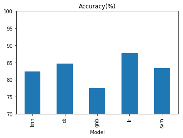

| Model | Accuracy (%) |
| --- | --- |
| lr | 87.7551 |
| dt | 84.6939 |
| svm | 83.3333 |
| knn | 82.3129 |
| gnb | 77.551 |

```python
# 将结果以图像展示出来
results_df = pd.DataFrame(columns=['Accuracy (%)'],index=['knn','dt','gnb','lr','svm'])
results_df.index.name = 'Model'
results_df.loc['knn', 'Accuracy (%)'] = max(knn_acc) * 100
results_df.loc['dt', 'Accuracy (%)'] = max(dt_acc) * 100
results_df.loc['gnb', 'Accuracy (%)'] = max(gnb_acc) * 100
results_df.loc['lr', 'Accuracy (%)'] = max(lr_acc) * 100
results_df.loc['svm', 'Accuracy (%)'] = max(svm_acc) * 100

plt.figure(figsize=(10, 4))
ax1 = plt.subplot(1, 2, 1)
results_df.plot(y=['Accuracy (%)'], kind='bar', ylim=[70, 100],
                ax=ax1, title='Accuracy(%)', legend=False)

plt.tight_layout()
plt.show()

results_df.sort_values(by='Accuracy (%)', ascending=False)
```

### F1值比较

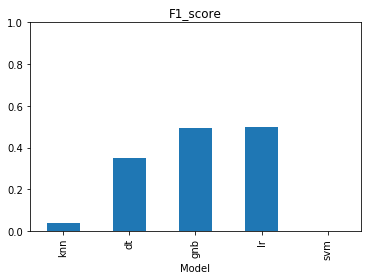

| Model | F1 |
| --- | --- |
| lr | 0.5 |
| gnb | 0.492308 |
| dt | 0.347826 |
| knn | 0.037037 |
| svm | 0 |

```python
from sklearn.metrics import f1_score

# 计算以上五个模型的F1值，保存在dataframe类型的变量results_df中并绘制成柱形图
results_df = pd.DataFrame(columns=['F1'],index=['knn','dt','gnb','lr','svm'])
results_df.index.name = 'Model'

knn = KNeighborsClassifier(n_neighbors=9)
knn.fit(X_train, y_train)
results_df.loc['knn', 'F1'] = f1_score(y_test, knn.predict(X_test))

dt = DecisionTreeClassifier(max_depth=5)
dt.fit(X_train, y_train)
results_df.loc['dt', 'F1'] = f1_score(y_test, dt.predict(X_test))

results_df.loc['gnb', 'F1'] = f1_score(y_test, gnb_model.predict(X_test))

results_df.loc['lr', 'F1'] = f1_score(y_test, lr_model.predict(X_test))

results_df.loc['svm', 'F1'] = f1_score(y_test, svm_model.predict(X_test))

plt.figure(figsize=(10, 4))
ax2 = plt.subplot(1, 2, 1)
results_df.plot(y=['F1'], kind='bar', ylim=[0, 1], ax=ax2, title='F1_score', legend=False)

plt.tight_layout()
plt.show()

results_df.sort_values(by='F1', ascending=False)
```

**准确率是指判断结果为离职的正确的概率，与之相对的是查全率，是指识别出来的离职员工数量占全部要离职员工的数量的百分比。F1指标认为准确率和召回率（查全率）两者具有相同的权重。再加上，如果企业投入了大量时间和金钱的员工离开，那么这意味着企业将不得不花费更多的时间和金钱来雇佣其他人。因此潜在的离职员工被识别出来更加重要，F1指标更加适合**